# R_learning_iml_3

Hector Hao

2019/4/30

# 第一章 自带解释性的方法: robust regression

这章研究一下robust regression.本质是回归诊断。

此外，本章继续尝试解释模型的封装。

## 线性回归的基本术语再回顾

- residual 残差

残差指观测值和估计值的差。

- outlier 离群值

指残差过大的数据点。

- leverage 杠杆值

自变量值远离变量均值的程度。高杠杆值意味着样本对模型参数的影响大。

- influence 影响

如果去掉某个样本，函数参数估计的变化大小。influence是leverage & outlierness的综合结果。

- Cook’s distance

Cook’s D， residual & leverage的综合结果。

- robust regression

对于一些影响较大的点，给较小的权重，影响较小的点给较大的权重，而不是简单地靠删去样本。

```r
summary(cdata)
```

```
      sid          state               crime            murder          pctmetro
 Min.   : 1.0   Length:51          Min.   :  82.0   Min.   : 1.600   Min.   : 24.00
 1st Qu.:13.5   Class :character   1st Qu.: 326.5   1st Qu.: 3.900   1st Qu.: 49.55
 Median :26.0   Mode  :character   Median : 515.0   Median : 6.800   Median : 69.80
 Mean   :26.0                      Mean   : 612.8   Mean   : 8.727   Mean   : 67.39
 3rd Qu.:38.5                      3rd Qu.: 773.0   3rd Qu.:10.350   3rd Qu.: 83.95
 Max.   :51.0                      Max.   :2922.0   Max.   :78.500   Max.   :100.00
    pctwhite         pcths          poverty          single
 Min.   :31.80   Min.   :64.30   Min.   : 8.00   Min.   : 8.40
 1st Qu.:79.35   1st Qu.:73.50   1st Qu.:10.70   1st Qu.:10.05
 Median :87.60   Median :76.70   Median :13.10   Median :10.90
 Mean   :84.12   Mean   :76.22   Mean   :14.26   Mean   :11.33
 3rd Qu.:92.60   3rd Qu.:80.10   3rd Qu.:17.40   3rd Qu.:12.05
 Max.   :98.50   Max.   :86.60   Max.   :26.40   Max.   :22.10
```

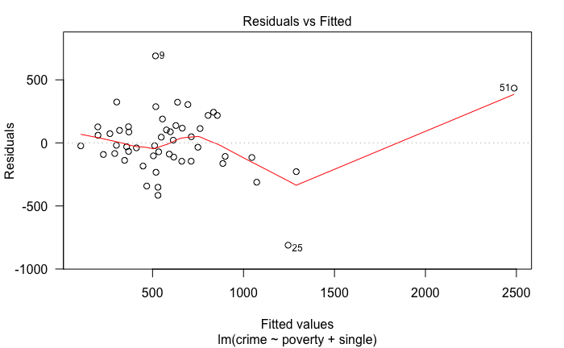

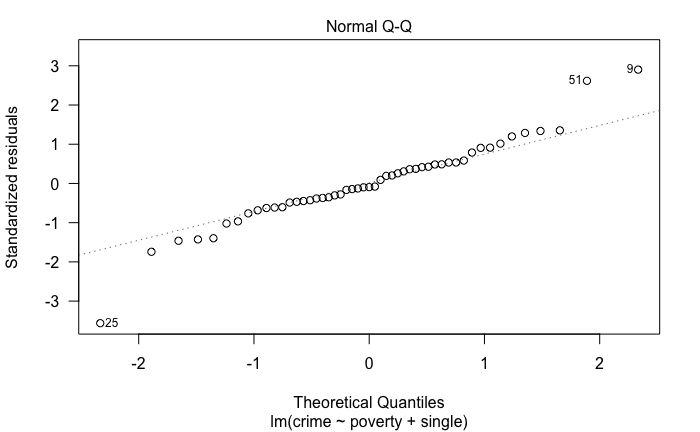

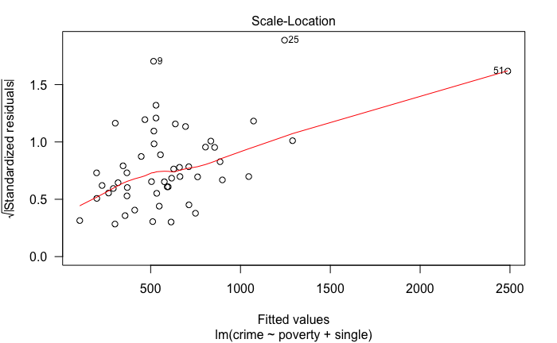

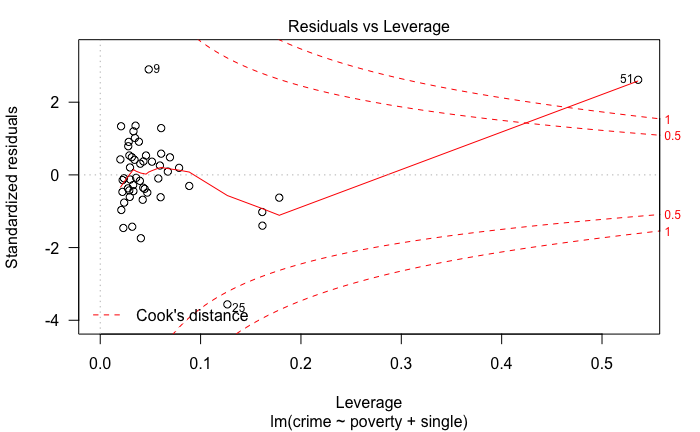

四张图分别有自己的含义。

第一张：outlier 和 high leverage点都标在图中了。横轴是y值，纵轴是残差。

第二张：违背正态性假设的数据点

第三张：scaled location plot

标准化残差，应该是一条横线。如果不是横线，那图中会标出关键的影响值。

第四张：cook’s D

宽松标准是大于1则是离群值。保守标准是 4/n.

求cook’s distance的步骤

```r
str(a[dis > 4/51,])
```

```
'data.frame':   4 obs. of  11 variables:
 $ sid     : num  1 9 25 51
 $ state   : chr  "ak" "fl" "ms" "dc"
 $ crime   : int  761 1206 434 2922
 $ murder  : num  9 8.9 13.5 78.5
 $ pctmetro: num  41.8 93 30.7 100
 $ pctwhite: num  75.2 83.5 63.3 31.8
 $ pcths   : num  86.6 74.4 64.3 73.1
 $ poverty : num  9.1 17.8 24.7 26.4
 $ single  : num  14.3 10.6 14.7 22.1
 $ dis     : num  0.125 0.143 0.614 2.636
 $ r       : num  -1.4 2.9 -3.56 2.62
```

```r
# then robust linear reg.
summary(rr.huber <- rlm(crime ~ poverty + single, data = cdata))
```

```
Call: rlm(formula = crime ~ poverty + single, data = cdata)
Residuals:
    Min      1Q  Median      3Q     Max
-846.09 -125.80  -16.49  119.15  679.94

Coefficients:
            Value      Std. Error t value
(Intercept) -1423.0373   167.5899    -8.4912
poverty         8.8677     8.0467     1.1020
single        168.9858    17.3878     9.7186

Residual standard error: 181.8 on 48 degrees of freedom
```

|  | state | resid | weight |
| --- | --- | --- | --- |
| 25 | ms | -846.08536 | 0.2889618 |
| 9 | fl | 679.94327 | 0.3595480 |
| 46 | vt | -410.48310 | 0.5955740 |
| 51 | dc | 376.34468 | 0.6494131 |
| 26 | mt | -356.13760 | 0.6864625 |
| 21 | me | -337.09622 | 0.7252263 |
| 31 | nj | 331.11603 | 0.7383578 |
| 14 | il | 319.10036 | 0.7661169 |
| 1 | ak | -313.15532 | 0.7807432 |
| 20 | md | 307.19142 | 0.7958154 |

[output cut: 5 more lines]